# Sedimentation stress to tagged corals: partial and total burial

# Setup

```r
# Load packages
library(MASS)
library(tidyverse)
library(lubridate)
library(lme4)
library(lsmeans)
library(mgcv)
library(gamm4)
library(furrr)

# Convert logit to probability
logit2prob <- function(logit){
  odds <- exp(logit)
  prob <- odds / (1 + odds)
  return(prob)
}

# Plan for parallel processing
plan(multiprocess)
```

# Import data

We will analyze the complete tagged coral dataset.

```r
# Import tidy tagged coral data
load("data/processed/tagged.RData")
tagged_bool <- tagged_bool %>%
  filter(!site %in% c("HBN1", "HBN2")) %>%                    # Omit HBN1 and HBN2
  mutate(day = (date - min(date)) / ddays(1))

# Define start and end of dredging (for plotting)
dredge.start.date <- as.Date("2013-11-20")                # NOAA sediment report April 2016, page 44
dredge.end.date <- as.Date("2015-03-16")                  # DCA report August 2015, page 3
```

#### Quantifying sedimentation stress

Several different condition codes were used to document impacts of sedimentation on corals:

- SA = sediment accumulation on the colony
- PBUR = partial burial of the colony
- BUR = complete burial of the colony

First we will look at all three of these codes as indicators of general sedimentation stress. Then we will look at only the more severe conditions - PBUR and BUR.

# All sedimentation stress conditions (SA, PBUR, and BUR)

### Proportion of corals with sedimentation stress over time for each site

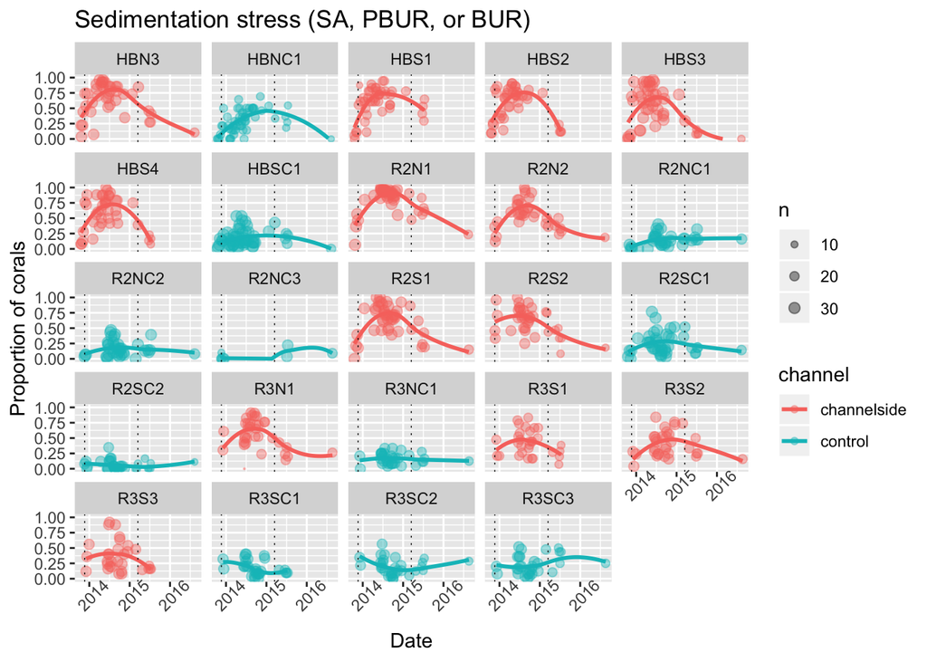

```r
# Get proportion of living corals with sedimentation stress for each reef/dir at each week
sedstress.summ1 <- tagged_bool %>%
  filter(!DEAD) %>%
  group_by(reef, dir, channel, site, date) %>%
  summarise(n = n(),
            SEDSTRESS = sum(SA|PBUR|BUR),
            prop = SEDSTRESS / n)

# Plot proportions
ggplot(sedstress.summ1, aes(x = date, y = prop, color = channel)) +
  facet_wrap(site ~ .) + ylim(0, 1) +
  geom_point(aes(size = n), alpha = 0.4) +
  scale_size(range = c(0.1, 2.5)) +
  geom_smooth(method = "loess", se = FALSE, span = 1) +
  labs(title = "Sedimentation stress (SA, PBUR, or BUR)",
       x = "Date", y = "Proportion of corals") +
  geom_vline(xintercept = c(dredge.start.date, dredge.end.date), lwd = 0.25, linetype = 3) +
  theme(axis.text.x = element_text(angle = 45))
```

These plots with local regression smoothing show that sedimentation stress was much greater at channelside sites relative to controls. To generate more robust statistical fits for the dataset and compare channelside vs. controls at each reef, we can fit generalized additive mixed models (GAMMs) and use only the regions in the data without large gaps in time.

### Model sedimentation stress using GAMMs

```r
# Filter dataset to only fit over regions with less than 20-week gaps between data points
tagged_bool_f <- tagged_bool %>%
  filter(!DEAD) %>%
  nest(-reef, -dir, -channel) %>%                                            # For each reef
  mutate(dates = map(data, ~ sort(unique(.$date))),                           # Which weeks have data
          runs = map(dates, ~ split(.x, cumsum(c(TRUE, diff(.x) > 140)))), # Find runs w/o 140d gaps
       longest = map(runs, ~ .x[[which.max(sapply(.x, length))]]),           # Get longest run
        data.f = map2(data, longest, ~ filter(.x, .$date %in% .y))) %>%  # Get data from those days
  unnest(data.f)

# Fit GAMMs for each reef
set.seed(55423)
gamms1 <- tagged_bool_f %>%
  # For each reef and direction
  nest(-reef, -dir) %>%
  mutate(
    # Fit a binomial GAMM for sediment stress over time at channelside vs. control, site as random
    mod = future_map(data, ~ gamm4(SA|PBUR|BUR ~ s(as.numeric(date), by = factor(channel)) + channel,
                                   random = ~ (1|site/transect) + (1|species),
                                   family = "binomial", data = .)),
    # Get newdata frame for predict() using the appropriate range of weeks
    newdata = map(data, ~ expand.grid(date = as.numeric(min(.$date):max(.$date)),
                                      channel = c("channelside", "control"))),
    # Get fitted values from GAMM using newdata frame
    fit = map2(mod, newdata, ~ predict(object = .x$gam, newdata = .y, type = "response")),
    # Get confidence intervals by simulation
    Rbeta = map(mod, ~ mvrnorm(n = 1000, coef(.$gam), vcov(.$gam))),
    Xp = map2(mod, newdata, ~ predict(object = .x$gam, newdata = .y, type = "lpmatrix")),
    sim = map2(Xp, Rbeta, function(x, y) x %*% t(y)),
    lci = map(sim, ~ logit2prob(apply(., 1, quantile, 0.025))),
    uci = map(sim, ~ logit2prob(apply(., 1, quantile, 0.975)))
  )

gamms1.fitted <- gamms1 %>%
  unnest(newdata, fit, lci, uci) %>%
  mutate(date = zoo::as.Date.numeric(date))
```

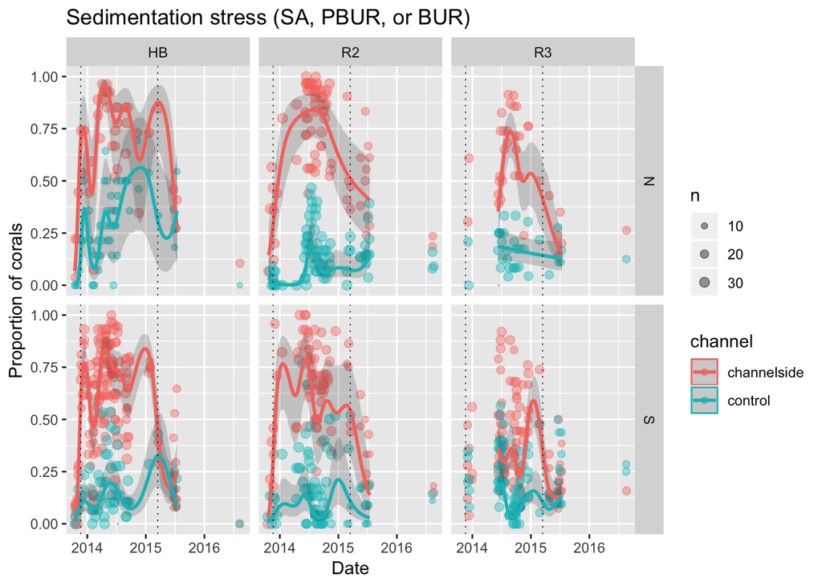

```r
# Plot
fig1 <- ggplot(gamms1.fitted, aes(x = date, y = fit, color = channel)) +
  facet_grid(dir ~ reef) +
  geom_point(data = sedstress.summ1, aes(y = prop, size = n), alpha = 0.4) +
  scale_size(range = c(0.1, 2.5)) +
  geom_ribbon(aes(ymin = lci, ymax = uci, linetype = NA), alpha = 0.2) +
  geom_line(lwd = 1) +
  geom_vline(xintercept = c(dredge.start.date, dredge.end.date), linetype = 3, lwd = 0.25) +
  labs(title = "Sedimentation stress (SA, PBUR, or BUR)",
       x = "Date", y = "Proportion of corals")

fig1
```

Why is there so much sediment stress at control sites, even those >9km away? Either some of these condition codes (e.g., SA) don’t really reflect dredging sediment, and/or the control sites were actually impacted by significant levels of dredging sediment.

# Severe sedimentation stress (PBUR or BUR, excluding SA)

If we assume that control sites are far enough from dredging activity that they are not impacted by dredging sediments, then the “SA” condition code, which was observed frequently at control sites (even those >9km away), may not be indicative of dredging sediments. Therefore, PBUR and BUR may be more appropriate indicators of sedimentation stress due to dredging.

### Proportion of corals with severe sedimentation stress over time for each site

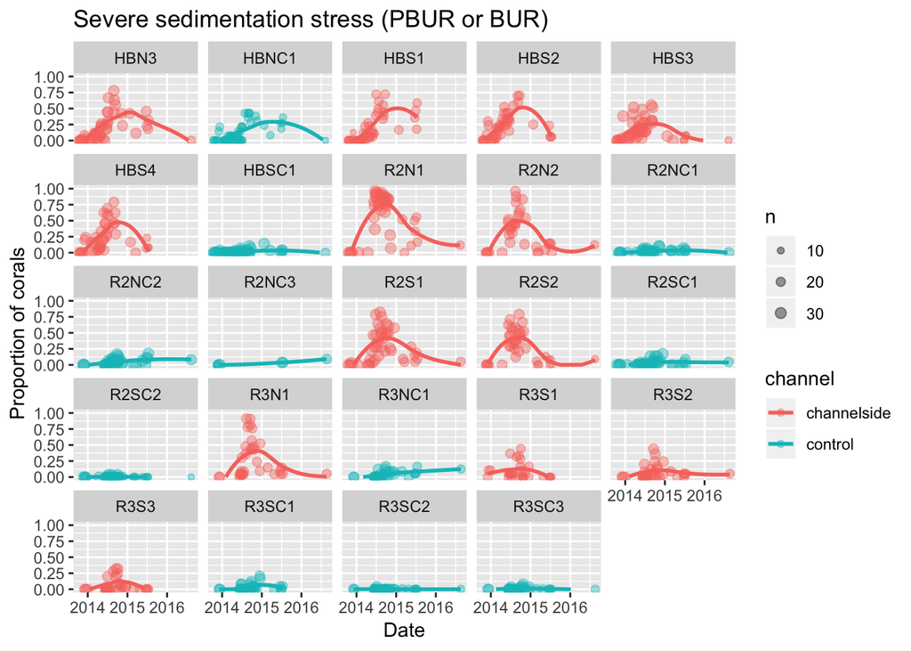

```r
# Get proportion of living corals with sedimentation stress for each reef/dir at each week
sedstress.summ2 <- tagged_bool %>%
  filter(!DEAD) %>%
  group_by(reef, dir, channel, site, date) %>%
  summarise(n = n(),
            SEDSTRESS = sum(PBUR|BUR),
            prop = SEDSTRESS / n)

# Plot proportions
ggplot(sedstress.summ2, aes(x = date, y = prop, color = channel)) +
  facet_wrap(site ~ .) + ylim(0, 1) +
  geom_point(aes(size = n), alpha = 0.4) +
  scale_size(range = c(0.1, 2.5)) +
  geom_smooth(method = "loess", se = FALSE, span = 1) +
  labs(title = "Severe sedimentation stress (PBUR or BUR)",
       x = "Date", y = "Proportion of corals")
```

### Model severe sedimentation stress using GAMMs

```r
# Fit GAMMs for each reef
set.seed(4327)
gamms2 <- tagged_bool_f %>%
  # For each reef (R2N, R2S, R3N, R3S)
  nest(-reef, -dir) %>%
  mutate(
    # Fit a binomial GAMM for sediment stress over time at channelside vs. control, site as random
    mod = future_map(data, ~ gamm4(PBUR|BUR ~ s(as.numeric(date), by = factor(channel)) + channel, #, k = 8
                                   random = ~ (1|site/transect) + (1|species),
                                   family = "binomial", data = .)),
    # Get newdata frame for predict() using the appropriate range of weeks
    newdata = map(data, ~ expand.grid(date = as.numeric(min(.$date):max(.$date)),
                                      channel = c("channelside", "control"))),
    # Get fitted values from GAMM using newdata frame
    fit = map2(mod, newdata, ~ predict(object = .x$gam, newdata = .y, type = "response")),
    # Get confidence intervals by simulation
    Rbeta = map(mod, ~ mvrnorm(n = 1000, coef(.$gam), vcov(.$gam))),
    Xp = map2(mod, newdata, ~ predict(object = .x$gam, newdata = .y, type = "lpmatrix")),
    sim = map2(Xp, Rbeta, function(x, y) x %*% t(y)),
    lci = map(sim, ~ logit2prob(apply(., 1, quantile, 0.025))),
    uci = map(sim, ~ logit2prob(apply(., 1, quantile, 0.975)))
  )

gamms2.fitted <- gamms2 %>%
  unnest(newdata, fit, lci, uci) %>%
  mutate(date = zoo::as.Date.numeric(date))

save(sedstress.summ2, gamms2.fitted, file = "data/processed/sedstress_gamms.RData")
```

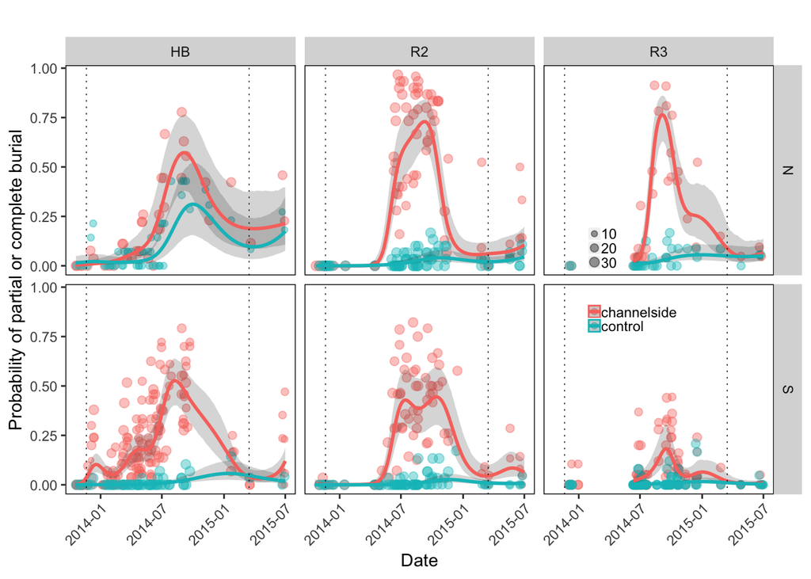

```r
# Plot
fig2 <- ggplot(gamms2.fitted, aes(x = date, y = fit, color = channel)) +
  facet_grid(dir ~ reef) +
  geom_point(data = sedstress.summ2, aes(y = prop, size = n), alpha = 0.4) +
  scale_size(range = c(0.1, 2.5)) +
  geom_ribbon(aes(ymin = lci, ymax = uci, linetype = NA), alpha = 0.2) +
  geom_line(lwd = 1) +
  geom_vline(xintercept = c(dredge.start.date, dredge.end.date), linetype = 3, lwd = 0.25) +
  labs(title = "Severe sedimentation stress (PBUR or BUR)",
       x = "Date", y = "Proportion of corals") +
  theme(axis.text.x = element_text(angle = 45, hjust = 1),
        panel.grid.minor = element_blank(), panel.background = element_blank(),
        panel.border = element_rect(color = "black", fill = NA),
        legend.position = c(0.8, 0.5), # c(0,0) bottom left, c(1,1) top-right.
        legend.background = element_rect(fill = NA, colour = NA),
        legend.title = element_blank(),
        legend.key.size = unit(0.3, "cm"))

fig2 + xlim(as.Date("2013-10-20"), as.Date("2015-07-01")) +
  labs(title = "", y = "Probability of partial or complete burial")
```

Analysis of PBUR or BUR only shows much lower prevalence of these condition codes at the farthest control sites, yet their prevalence at channelside sites (and some control sites, e.g., HBN) remains very high.

# Reported results

```r
load("data/processed/sedstress_gamms.RData")

# Number of corals PBUR or BUR before dredging began
sedstress.summ2 %>% ungroup() %>%
  filter(date < "2013-11-20") %>%
  summarise(nobs = sum(n),
            nsedstress = sum(SEDSTRESS))
```

```
## # A tibble: 1 x 2
##    nobs nsedstress
##   <int>      <int>
## 1  1151          1
```

```r
# Peak of sed stress
# What was the maximum coral burial observed in each area? Look at upper confidence limit on prediction, and when it occurred.
maxfit2014 <- gamms2.fitted %>%
  group_by(reef, dir, channel) %>%
  summarise(max_burial = round(max(fit) * 100, 1),
            when = date[fit == max(fit)])

knitr::kable(maxfit2014 %>% arrange(-max_burial),
             caption = "Maximum predicted prevalence of coral burial")
```

Maximum predicted prevalence of coral burial

| reef | dir | channel | max_burial | when |
| --- | --- | --- | --- | --- |
| R3 | N | channelside | 76.4 | 2014-09-05 |
| R2 | N | channelside | 72.9 | 2014-09-09 |
| HB | N | channelside | 57.2 | 2014-09-04 |
| HB | S | channelside | 52.7 | 2014-08-09 |
| R2 | S | channelside | 44.5 | 2014-10-14 |
| HB | N | control | 31.2 | 2014-10-01 |
| R3 | S | channelside | 18.3 | 2014-09-16 |
| HB | S | control | 5.7 | 2015-01-15 |
| R3 | N | control | 5.6 | 2014-12-30 |
| R2 | N | control | 5.4 | 2015-07-15 |
| R2 | S | control | 2.7 | 2014-11-20 |
| R3 | S | control | 1.7 | 2014-12-30 |